# Causal Inference - Exercise POs

Michael Knaus

SoSe 25

These are the goals of this notebook:

- Get a feeling how potential outcomes map to observed outcomes
- Using these potential outcomes, see how the difference in means decomposes into ATT and confounding bias

# Crowd-sourced potential outcomes

Let’s create data on both potential outcomes and some covariates. Follow the link to the [Google Form](https://forms.gle/4i7ourr4Q5qkxom36).

Of course, we can never know such things but for the sake of the illustration in this notebook, let’s assume that these are the real potential outcomes.

```
# Install and load all relevant packages for this session
if (!require("tidyverse")) install.packages("tidyverse", dependencies = TRUE); library(tidyverse)
if (!require("estimatr")) install.packages("estimatr", dependencies = TRUE); library(estimatr)
if (!require("qte")) install.packages("qte", dependencies = TRUE); library(qte)
```

## Creating the observable data

Now we fast forward into the future and draw a treatment indicating whether a person is reached this evening. To this end we get the probabilities you entered from a Google spreadsheet

```
# Access the data in the spreadsheet
url = "https://docs.google.com/spreadsheets/d/e/2PACX-1vS9cAqJYfoo_ct5BquBuauJE_7eLMiaHMfWzyjr1UeE1S7B_RpVCe7PIFGvLyRllI_ngDJ_6g92bMhx/pub?gid=87802790&single=true&output=csv"

set.seed(1234) # For replicability

# Extract answers to "What is the probability the person picks up the phone?"
answer_prob = unlist(read_csv(url)[[5]])
hist(answer_prob)
```

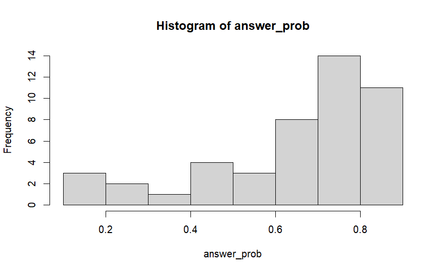

and we draw the treatment status, i.e. we simulate a potential future in which some of you reach the person and some don’t:

```
N = length(answer_prob) # Extracts number of observations
W = rbinom(N, 1, answer_prob) # treatment indicators drawn from prob(i picks up)
table(W)
```

```
W
 0  1
13 33
```

Suppose further that we could afterwards measure the life satisfaction of each person and this would be the value you have guessed to occur under the assigned treatment $Y = W Y(1) + (1-W) Y(0)$.

```
# Create "observed" data
data = read_csv(url) %>%
  dplyr::select(2:6) %>%
  mutate(W = W) %>%
  mutate(Y = ifelse(W == 1, .[[5]], .[[1]])) %>% # Y = W Y(1) + (1-W) Y(0)
  dplyr::select(-1,-5)

# Create "observed" Y, X
Y = unlist(data[,5])
X = data[, c(1, 2)]
colnames(X) =  c("age", "in.Germany")
```

### Descriptive statistics

Let’s see what kind of data set we get. First, let’s check how the characteristics differ between treated and control groups. We can do this visually:

```
df = data.frame(age = X$age, in.Germany = X$in.Germany, treatment = factor(W))

# Plot 1: Overlaid histograms of age using density
ggplot(df, aes(x = age, fill = treatment)) +
  scale_fill_manual(values = c('orange', 'dodgerblue')) +
  geom_histogram(aes(y = after_stat(density)), position = "identity", alpha = 0.6, binwidth = 10, color = "black") +
  labs(fill = "Treatment Group", x = "Age", y = "Density") +
  theme_minimal() +
  ggtitle("Overlaid Histograms of Age (Density)") +
  theme(legend.position = "bottom")
```

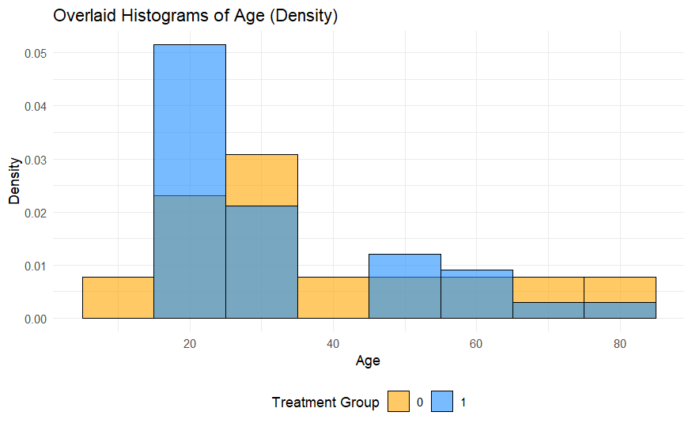

```
# Plot 2: Proportional bar plot of in.Germany
ggplot(df, aes(x = factor(in.Germany), fill = treatment)) +
  scale_fill_manual(values = c('#febf6b', '#76aeff')) +
  geom_bar(position = "fill", color = "black") +
  theme_minimal() +
  labs(fill = "Treatment Group", x = "Lives in Germany", y = "Proportion") +
  ggtitle("Proportion by Treatment Group: Lives in Germany") +
  theme(legend.position = "bottom")
```

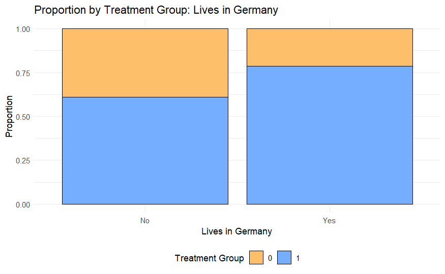

What else could we check?

```
age = unlist(X[,1])
cat("\nMean age in treated group:", mean(age[W==1]),
    "\nMean age in control group:", mean(age[W==0]))
```

```
Mean age in treated group: 33.60606
Mean age in control group: 38.53846
```

### Decomposing (Naive) Group Comparisons

The “naive” mean difference is

```
naive_estimate = mean(Y[W == 1]) - mean(Y[W == 0])
naive_estimate
```

```
[1] 1.251748
```

which is identical to the OLS coefficient:

```
summary(lm_robust(Y ~ W))
```

```
Call:
lm_robust(formula = Y ~ W)

Standard error type:  HC2

Coefficients:
            Estimate Std. Error t value  Pr(>|t|) CI Lower CI Upper DF
(Intercept)    6.385     0.5722  11.158 2.046e-14  5.23142    7.538 44
W              1.252     0.6362   1.968 5.544e-02 -0.03039    2.534 44

Multiple R-squared:  0.09919 ,  Adjusted R-squared:  0.07871
F-statistic: 3.871 on 1 and 44 DF,  p-value: 0.05544
```

Remember how SUTVA and consistency allow us to link observed and hypothetical distributions:

$$\begin{align*} \mathbb{E}&[Y \mid W=1] - \mathbb{E}[Y \mid W=0] \\
& = \mathbb{E}[\overbrace{(1-W)}^{=0} Y(0) + \overbrace{W}^{=1} Y(1)
\mid W=1] - \mathbb{E}[\overbrace{(1-W)}^{=1} Y(0) + \overbrace{W}^{=0}
Y(1) \mid W=0] \\ & = \mathbb{E}[Y(1) \mid W=1] - \mathbb{E}[Y(0)
\mid W=0] \\\end{align*}$$

Let’s review our setup: people are encouraged to take treatment (you try to call them), but only some answer the call, and only they receive the treatment. So actual treatment received $W$ is probably related your and their characteristics.

If the people who are actually reached have on average a higher/lower mood regardless of your call, then the observed difference in outcomes will not represent the pure effect of you calling, but is contaminated with confounding bias.

Following the lecture, we can decompose the mean comparison as

$$\begin{align*} \mathbb{E}&[Y \mid W=1] - \mathbb{E}[Y \mid W=0]
\\& = \mathbb{E}[Y(1) \mid W=1] - \mathbb{E}[Y(0) \mid W=0] \\&
= \mathbb{E}[Y(1) \mid W=1] - \mathbb{E}[Y(0) \mid W=0] \pm
\mathbb{E}[Y(0) \mid W=1] \\&=
\underbrace{\overbrace{\mathbb{E}[Y(1) \mid W=1]}^{factual} -
\overbrace{\mathbb{E}[Y(0) \mid W=1]}^{counterfactual}}_{\text{ATT}} +
\underbrace{\overbrace{\mathbb{E}[Y(0) \mid W=1]}^{counterfactual} -
\overbrace{\mathbb{E}[Y(0) \mid W=0]}^{factual}}_{\text{confounding
bias}}\end{align*}$$

Usually we have no way to get our hands on the counterfactual components. However, in this notebook we pretend to know the potential outcomes and can calculate each component. To this end, first extract the potential outcomes:

```
# Get the potential outcomes
data = read_csv(url)
Y0 = unlist(data[[2]])
Y1 = unlist(data[[6]])
```

Let’s ceck the potential outcome distributions:

```
hist(Y0)
```

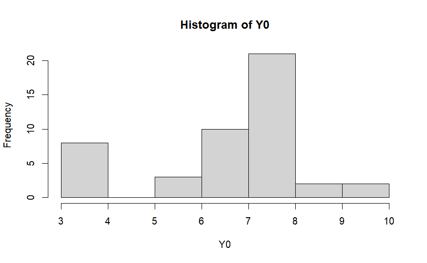

```
hist(Y1)
```

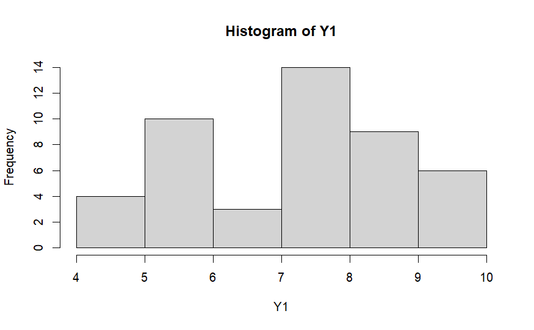

```
hist(Y1-Y0)
```

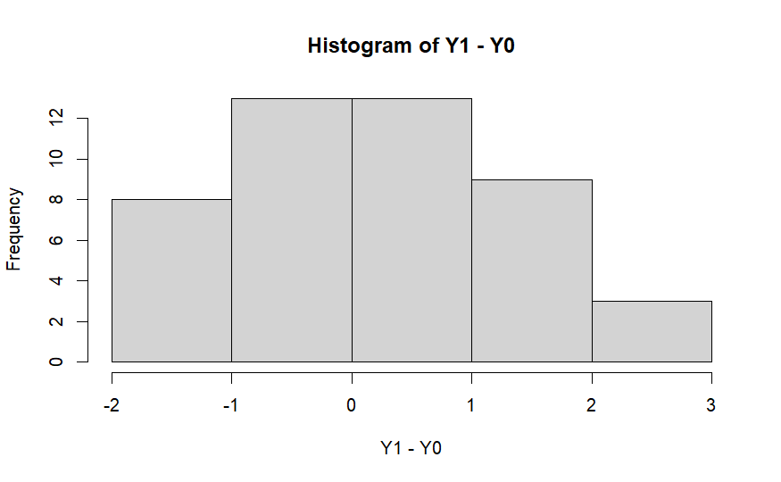

Next we can calculate the components of the decomposition

```
ATT = mean(Y1[W==1] - Y0[W==1])
confounding_bias = mean(Y0[W==1]) - mean(Y0[W==0])

cat("\nATT:", ATT,
    "\nConfounding bias:", confounding_bias)
```

```
ATT: 0.3636364
Confounding bias: 0.8881119
```

Finally let’s confirm as a sanity check that ATT+confounding bias are identical to the naive estimate:

```
all.equal(ATT+confounding_bias, naive_estimate)
```

```
[1] TRUE
```

This is just an illustration how we can think about the observed variable $Y$. First, there are two potential outcomes, then the assigned treatment decides which value becomes observable to us. In reality, we will never know the other potential outcome.